# Nonlinear Regression and PCA Results Outline

Allison Stewart, Christine Kuryla, Zander De Jesus, Alana Ferris

2024-03-24

These are preliminary analyses for non-linear regression of phthalate metabolites on AGP concentration and PCA of phthalate metabolites in children aged 3-16 years old.

Moving forward, should we include all the metabolites together in one model or run separate models for each metabolite? (there are 19 different metabolite alternatives) We’re thinking of including the 8 metabolites that had edf > 1 with splines in the final model and those with edf = 1 with no spline. Does this make sense?

# Non-linear exposure-response curves

```r
#metabolites: cnp, cop, ecp, ecpt, hipb, mbp, mc1, mcoh, mep, mhbp, mhh, mhht, mhnc, mhp, mib, mnp, moh, monp, mzp

#first fit linear model

lin_model <- lm(ssagp ~ cnp + cop + ecp + ecpt + hibp + mbp + mc1 + mcoh + mep + mhbp + mhh + mhht + mhnc + mhp + mib + mnp + moh + monp + mzp, data = exp_outcome)

summary(lin_model)
```

```
##
## Call:
## lm(formula = ssagp ~ cnp + cop + ecp + ecpt + hibp + mbp + mc1 +
##     mcoh + mep + mhbp + mhh + mhht + mhnc + mhp + mib + mnp +
##     moh + monp + mzp, data = exp_outcome)
##
## Residuals:
##      Min       1Q   Median       3Q      Max
## -0.50709 -0.17335 -0.01908  0.14308  1.22819
##
## Coefficients:
##               Estimate Std. Error t value Pr(>|t|)
## (Intercept)  7.977e-01  1.546e-02  51.599  < 2e-16 ***
## cnp         -2.414e+02  1.787e+03  -0.135  0.89257
## cop          1.882e+02  4.583e+02   0.411  0.68149
## ecp         -1.733e+03  1.366e+03  -1.268  0.20522
## ecpt        -6.264e+01  3.791e+01  -1.653  0.09892 .
## hibp        -2.589e+03  2.745e+03  -0.943  0.34590
## mbp         -3.169e+02  1.022e+03  -0.310  0.75657
## mc1         -7.928e+00  1.802e+02  -0.044  0.96493
## mcoh        -6.490e+03  5.797e+03  -1.120  0.26328
## mep          1.955e+01  2.679e+01   0.730  0.46575
## mhbp        -2.698e+03  1.072e+04  -0.252  0.80128
## mhh          2.854e+03  2.756e+03   1.036  0.30065
## mhht         2.026e+02  2.109e+02   0.961  0.33710
## mhnc         3.028e+03  3.096e+03   0.978  0.32841
## mhp         -1.538e+04  5.186e+03  -2.966  0.00312 **
## mib          7.184e+02  1.288e+03   0.558  0.57733
## mnp          1.412e+03  4.031e+03   0.350  0.72628
## moh          2.181e+03  5.247e+03   0.416  0.67786
## monp        -1.188e+03  2.026e+03  -0.586  0.55785
## mzp          8.736e+01  3.997e+02   0.219  0.82708
## ---
## Signif. codes:  0 '***' 0.001 '**' 0.01 '*' 0.05 '.' 0.1 ' ' 1
##
## Residual standard error: 0.2432 on 642 degrees of freedom
##   (27 observations deleted due to missingness)
## Multiple R-squared:  0.0368, Adjusted R-squared:  0.008294
## F-statistic: 1.291 on 19 and 642 DF,  p-value: 0.1817
```

```r
#fit complete model with penalized splines

total_model <- gam(ssagp  ~ s(cnp) + s(cop) + s(ecp) + s(ecpt) + s(hibp) + s(mbp) + s(mc1) + s(mcoh) + s(mep) + s(mhbp) + s(mhh) + s(mhht) + s(mhnc) + s(mhp) + s(mib) + s(mnp) + s(moh) + s(monp) + s(mzp), data = exp_outcome)

summary(total_model)
```

```
##
## Family: gaussian
## Link function: identity
##
## Formula:
## ssagp ~ s(cnp) + s(cop) + s(ecp) + s(ecpt) + s(hibp) + s(mbp) +
##     s(mc1) + s(mcoh) + s(mep) + s(mhbp) + s(mhh) + s(mhht) +
##     s(mhnc) + s(mhp) + s(mib) + s(mnp) + s(moh) + s(monp) + s(mzp)
##
## Parametric coefficients:
##             Estimate Std. Error t value Pr(>|t|)
## (Intercept) 0.758021   0.009116   83.15   <2e-16 ***
## ---
## Signif. codes:  0 '***' 0.001 '**' 0.01 '*' 0.05 '.' 0.1 ' ' 1
##
## Approximate significance of smooth terms:
##           edf Ref.df     F p-value
## s(cnp)  1.000  1.000 0.268  0.6051
## s(cop)  1.000  1.000 0.200  0.6545
## s(ecp)  1.000  1.000 0.107  0.7434
## s(ecpt) 1.715  2.065 2.583  0.0743 .
## s(hibp) 1.000  1.000 0.313  0.5758
## s(mbp)  1.000  1.000 0.709  0.4002
## s(mc1)  1.000  1.000 0.042  0.8377
## s(mcoh) 6.216  7.079 1.267  0.2658
## s(mep)  3.279  3.878 1.149  0.2691
## s(mhbp) 1.000  1.000 0.340  0.5601
## s(mhh)  1.000  1.000 0.003  0.9542
## s(mhht) 2.103  2.602 1.719  0.1690
## s(mhnc) 4.846  5.746 1.325  0.3967
## s(mhp)  2.109  2.632 3.844  0.0104 *
## s(mib)  1.000  1.000 0.054  0.8158
## s(mnp)  3.763  4.585 1.374  0.2839
## s(moh)  1.000  1.000 0.390  0.5326
## s(monp) 1.000  1.000 1.309  0.2530
## s(mzp)  1.709  2.107 0.509  0.5815
## ---
## Signif. codes:  0 '***' 0.001 '**' 0.01 '*' 0.05 '.' 0.1 ' ' 1
##
## R-sq.(adj) =  0.0773   Deviance explained = 12.9%
## GCV = 0.058345  Scale est. = 0.055019  n = 662
```

```r
#edf not equal to 1 for ecpt, mcoh, mep, mhht, mhnc, mhp, mnp, mzp
#going to fit GAM models with penalized splines for those 8 metabolites
```

### Indidual penalized splines for each metabolite with edf > 1

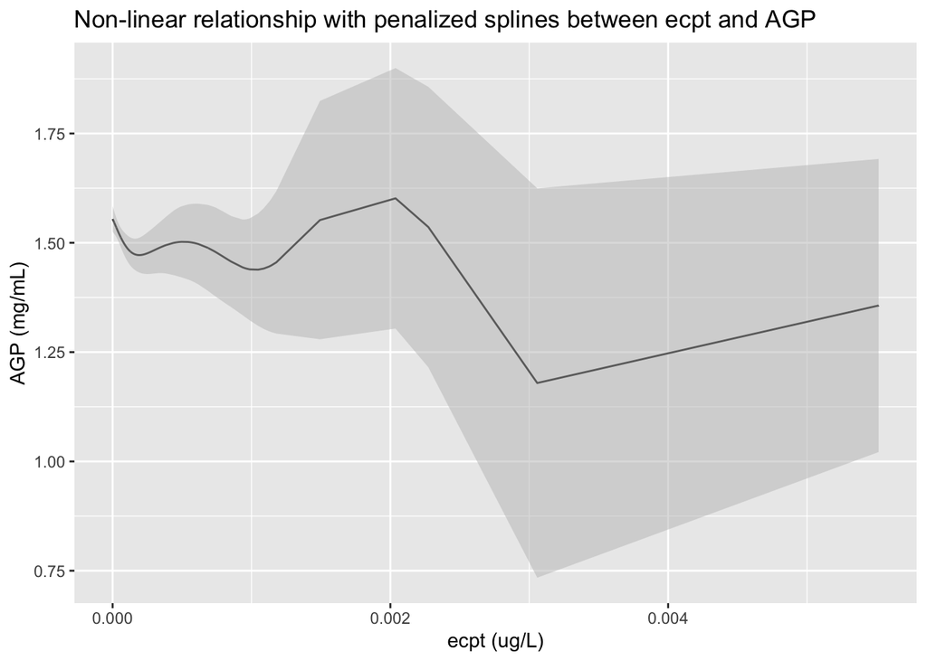

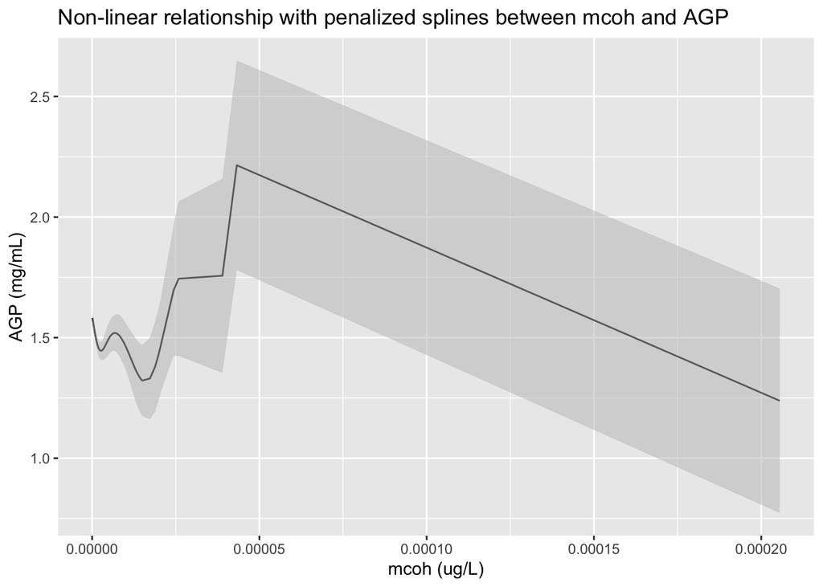

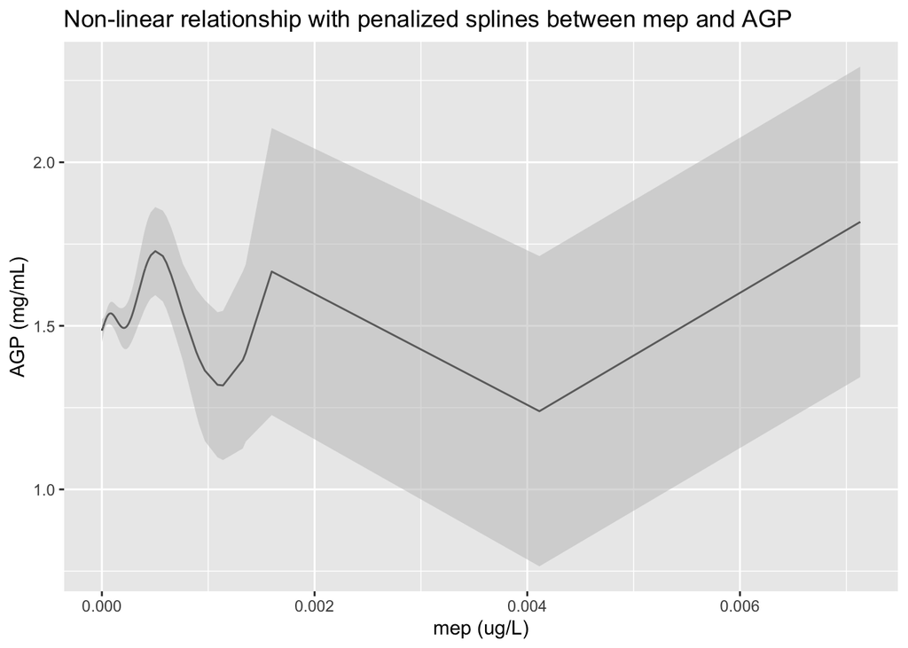

```r
# Fit GAM model for ecpt with penalized spline
ecpt_model <- gam(ssagp ~ s(ecpt), data = exp_outcome)

# Generate predictions and standard errors
pred_ecpt <- predict(ecpt_model, se.fit = TRUE)

# Create dataframe for predictions and standard errors
pred_ecpt_df <- data.frame(
  pred_centered = pred_ecpt$fit,
  se = pred_ecpt$se.fit,
  lci_centered = pred_ecpt$fit - 1.96 * pred_ecpt$se.fit,
  uci_centered = pred_ecpt$fit + 1.96 * pred_ecpt$se.fit
)

#exclude missing values from original dataset and bind two datasets
exp_outcome <- exp_outcome[complete.cases(exp_outcome), ]

# Combine predictions and original dataset
pred_ecpt_df <- cbind(exp_outcome, pred_ecpt_df)|>
  mutate(metabolite_model = "ecpt")

# Uncenter data
pred_ecpt_df$pred_agp <- pred_ecpt_df$pred_centered + mean(exp_outcome$ssagp)
pred_ecpt_df$lci_agp <- pred_ecpt_df$lci_centered + mean(exp_outcome$ssagp)
pred_ecpt_df$uci_agp <- pred_ecpt_df$uci_centered + mean(exp_outcome$ssagp)

# Plot
ggplot(pred_ecpt_df, aes(x = ecpt, y = pred_agp)) +
  geom_line() +
  geom_ribbon(aes(ymin = lci_agp, ymax = uci_agp), fill = "grey", alpha = 0.5) +
  xlab("ecpt (ug/L)") +
  ylab("AGP (mg/mL)") +
ggtitle("Non-linear relationship with penalized splines between ecpt and AGP")
```

The mhht model below is likely not showing any reportable data due to the increasingly wide confidence interval at higher levels of metabolite concentration

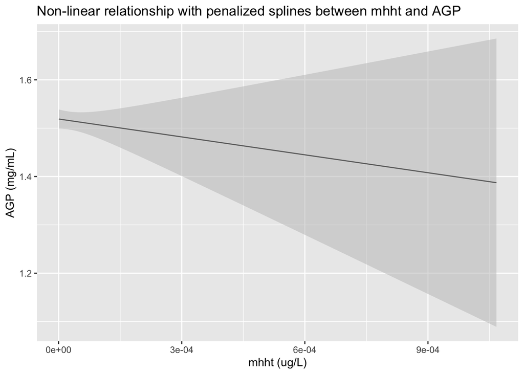

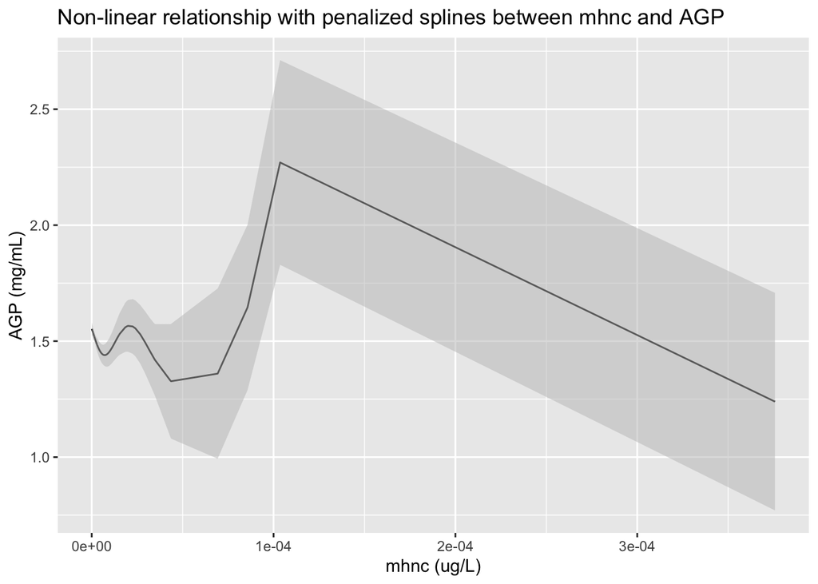

This one also has an extremely wide confidence interval at larger values

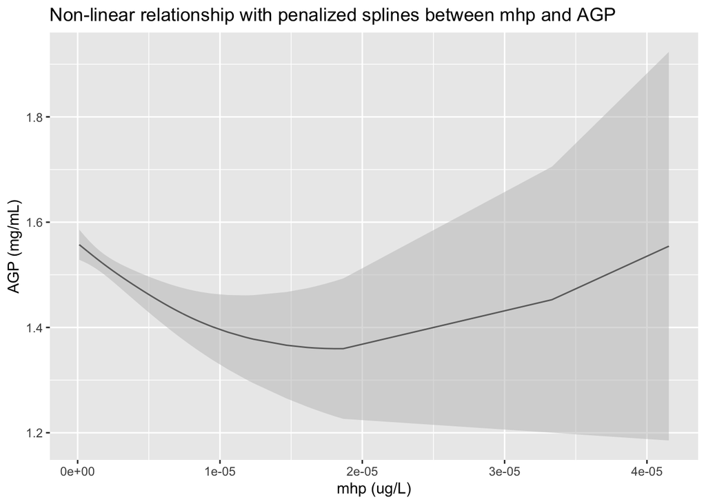

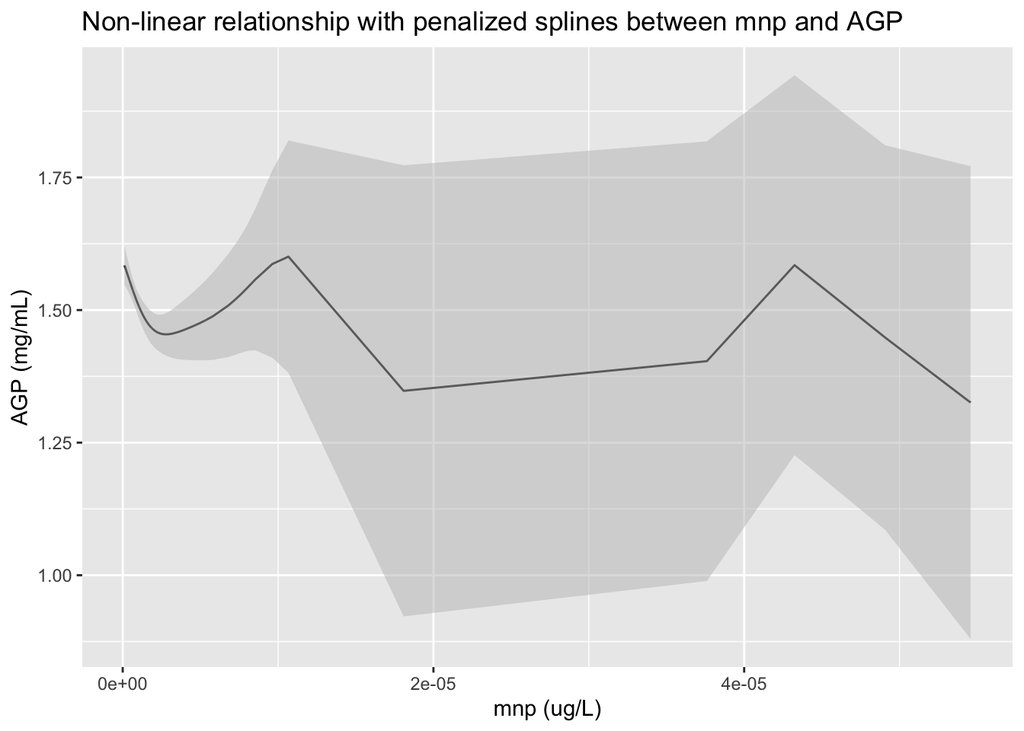

Another situation with very wide confidence intervals at higher metabolite concentrations

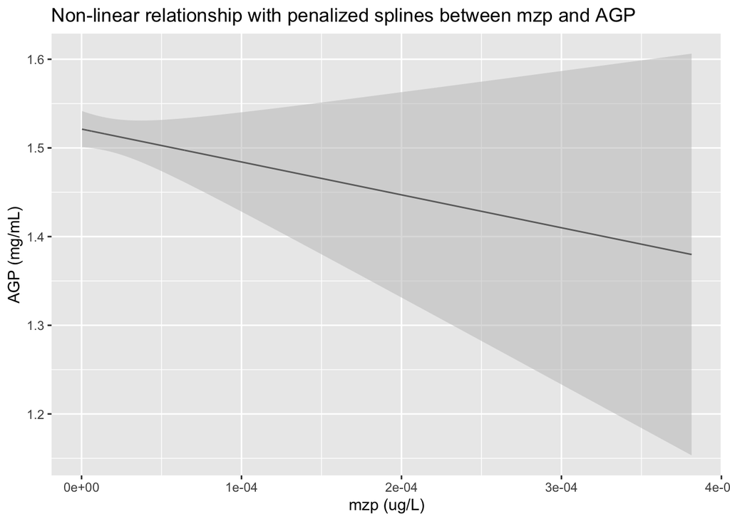